# R Notebook

# Weekend homework Week 11 - logistic regression

You have been provided with a set of data on customer purchases of either ‘Citrus Hill’ (purchase = ‘CH’) or ‘Minute Maid’ (purchase = ‘MM’) orange juice, together with some further attributes of both the customer and the store of purchase. A data dictionary is also provided in the data directory.

We would like you to build the best predictive classifier you can of whether a customer is likely to buy Citrus Hill or Minute Maid juice. Use logistic regression to do this. You should use either train-test splitting or cross-validation to evaluate your classifier. The metric for ‘best classifier’ will be highest AUC value either in the test set (for train-test splitting) or from cross-validation.

```r
library(pROC)
```

| purchase | weekof_purchase | store_id | price_ch | price_mm | disc_ch | disc_mm | special_ch | special_mm | loyal_ch | sale_price_mm | sale_price_ch | price_diff | store7 | pct_disc_mm | pct_disc_ch | list_price_diff | store |
| --- | --- | --- | --- | --- | --- | --- | --- | --- | --- | --- | --- | --- | --- | --- | --- | --- | --- |
| CH | 237 | 1 | 1.75 | 1.99 | 0.00 | 0.0 | 0 | 0 | 0.500000 | 1.99 | 1.75 | 0.24 | No | 0.000000 | 0.000000 | 0.24 | 1 |
| CH | 239 | 1 | 1.75 | 1.99 | 0.00 | 0.3 | 0 | 1 | 0.600000 | 1.69 | 1.75 | -0.06 | No | 0.150754 | 0.000000 | 0.24 | 1 |
| CH | 245 | 1 | 1.86 | 2.09 | 0.17 | 0.0 | 0 | 0 | 0.680000 | 2.09 | 1.69 | 0.40 | No | 0.000000 | 0.091398 | 0.23 | 1 |
| MM | 227 | 1 | 1.69 | 1.69 | 0.00 | 0.0 | 0 | 0 | 0.400000 | 1.69 | 1.69 | 0.00 | No | 0.000000 | 0.000000 | 0.00 | 1 |
| CH | 228 | 7 | 1.69 | 1.69 | 0.00 | 0.0 | 0 | 0 | 0.956535 | 1.69 | 1.69 | 0.00 | Yes | 0.000000 | 0.000000 | 0.00 | 0 |
| CH | 230 | 7 | 1.69 | 1.99 | 0.00 | 0.0 | 0 | 1 | 0.965228 | 1.99 | 1.69 | 0.30 | Yes | 0.000000 | 0.000000 | 0.30 | 0 |

There are no missing values. There are 16 numeric variables, 2 character.

We need to wrangle some variables: 1. dependent variable Purchase -> logical variable, e.g. purchase_mm 2. storeID -> factor 3. WeekofPurchase -> I decide to leave it in as numerical, potentially there is a relation with week number throughout the year and specific brand. 4. SpecialCH / SpecialMM -> factor 5. Store7 -> logical variable 6. STORE -> factor

```r
#wrangle the variables
orange_data <- orange %>%
    mutate(purchase_mm = if_else(purchase == "MM", TRUE, FALSE), .before = purchase) %>%
    mutate(store_id = as_factor(store_id),
           special_ch = as_logical(special_ch),
           special_mm = as_logical(special_mm),
           store7 = if_else(store7 == "Yes", TRUE, FALSE),
           store = as_factor(store)) %>%
    select(-purchase)
```

[output not shown]

### look at alliased variables

```r
alias(purchase_mm ~ ., data = orange_data)
```

```
Model :
purchase_mm ~ weekof_purchase + store_id + price_ch + price_mm +
    disc_ch + disc_mm + special_ch + special_mm + loyal_ch +
    sale_price_mm + sale_price_ch + price_diff + store7 + pct_disc_mm +
    pct_disc_ch + list_price_diff + store

Complete :
                (Intercept) weekof_purchase store_id2 store_id3 store_id4 store_id7 price_ch price_mm disc_ch disc_mm special_chTRUE special_mmTRUE loyal_ch
sale_price_mm    0           0               0         0         0         0         0        1        0      -1       0              0              0
sale_price_ch    0           0               0         0         0         0         1        0       -1       0       0              0              0
price_diff       0           0               0         0         0         0        -1        1        1      -1       0              0              0
store7TRUE       0           0               0         0         0         1         0        0        0       0       0              0              0
list_price_diff  0           0               0         0         0         0        -1        1        0       0       0              0              0
store1           1           0              -1        -1        -1        -1         0        0        0       0       0              0              0
store2           0           0               1         0         0         0         0        0        0       0       0              0              0
store3           0           0               0         1         0         0         0        0        0       0       0              0              0
store4           0           0               0         0         1         0         0        0        0       0       0              0              0
                pct_disc_mm pct_disc_ch
sale_price_mm    0           0
sale_price_ch    0           0
price_diff       0           0
store7TRUE       0           0
list_price_diff  0           0
store1           0           0
store2           0           0
store3           0           0
store4           0           0
```

Output gives the aliases: sale_price_mm, sale_price_ch, price_diff, store7TRUE, list_price_diff, store

Let’s drop these!

| purchase_mm | weekof_purchase | store_id | price_ch | price_mm | disc_ch | disc_mm | special_ch | special_mm | loyal_ch | pct_disc_mm | pct_disc_ch |
| --- | --- | --- | --- | --- | --- | --- | --- | --- | --- | --- | --- |
| FALSE | 237 | 1 | 1.75 | 1.99 | 0.00 | 0.00 | FALSE | FALSE | 0.500000 | 0.000000 | 0.000000 |
| FALSE | 239 | 1 | 1.75 | 1.99 | 0.00 | 0.30 | FALSE | TRUE | 0.600000 | 0.150754 | 0.000000 |
| FALSE | 245 | 1 | 1.86 | 2.09 | 0.17 | 0.00 | FALSE | FALSE | 0.680000 | 0.000000 | 0.091398 |
| TRUE | 227 | 1 | 1.69 | 1.69 | 0.00 | 0.00 | FALSE | FALSE | 0.400000 | 0.000000 | 0.000000 |
| FALSE | 228 | 7 | 1.69 | 1.69 | 0.00 | 0.00 | FALSE | FALSE | 0.956535 | 0.000000 | 0.000000 |
| FALSE | 230 | 7 | 1.69 | 1.99 | 0.00 | 0.00 | FALSE | TRUE | 0.965228 | 0.000000 | 0.000000 |
| FALSE | 232 | 7 | 1.69 | 1.99 | 0.00 | 0.40 | TRUE | TRUE | 0.972182 | 0.201005 | 0.000000 |
| FALSE | 234 | 7 | 1.75 | 1.99 | 0.00 | 0.40 | TRUE | FALSE | 0.977746 | 0.201005 | 0.000000 |
| FALSE | 235 | 7 | 1.75 | 1.99 | 0.00 | 0.40 | FALSE | FALSE | 0.982197 | 0.201005 | 0.000000 |
| FALSE | 238 | 7 | 1.75 | 1.99 | 0.00 | 0.40 | FALSE | FALSE | 0.985757 | 0.201005 | 0.000000 |

[output cut: 990 more lines]

No aliases remaining!

### look at realtionships of variables with purchase_mm

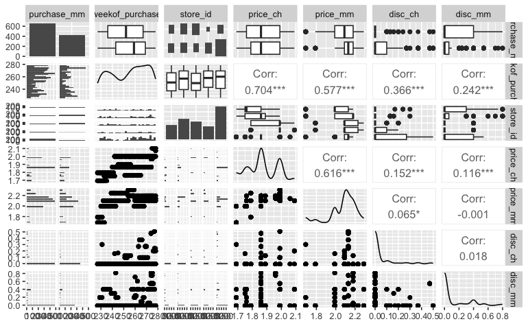

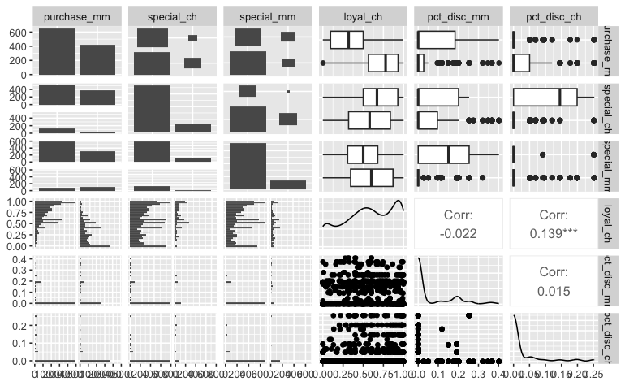

### Let’s build a model

build a model including the predictors that seemed to have a significant relation with purchase_mm above (and even took the questionable ones)

**model1**

```r
summary(purchase_mm_multi_logreg_model)
```

```
Call:
glm(formula = purchase_mm ~ loyal_ch + weekof_purchase + store_id +
    special_ch + special_mm + price_mm + price_ch, family = binomial(link = "logit"),
    data = orange_data_tidy)

Coefficients:
                Estimate Std. Error z value Pr(>|z|)
(Intercept)      2.45501    1.71046   1.435 0.151205
loyal_ch        -5.94420    0.38870 -15.293  < 2e-16 ***
weekof_purchase -0.01197    0.01035  -1.157 0.247351
store_id2        0.02325    0.27165   0.086 0.931793
store_id3       -0.25365    0.37622  -0.674 0.500182
store_id4       -0.58829    0.40805  -1.442 0.149384
store_id7       -0.75029    0.27801  -2.699 0.006959 **
special_chTRUE   0.13120    0.27905   0.470 0.638242
special_mmTRUE   0.87458    0.23400   3.737 0.000186 ***
price_mm        -3.06011    0.83801  -3.652 0.000261 ***
price_ch         5.24417    1.82214   2.878 0.004002 **
---
Signif. codes:  0 ‘***’ 0.001 ‘**’ 0.01 ‘*’ 0.05 ‘.’ 0.1 ‘ ’ 1

(Dispersion parameter for binomial family taken to be 1)

    Null deviance: 1430.85  on 1069  degrees of freedom
Residual deviance:  863.46  on 1059  degrees of freedom
AIC: 885.46

Number of Fisher Scoring iterations: 5
```

Based on the summary: following predictors seem to be significant: loyal_ch, store, special_mm, price_mm, price_ch

Check statistical significance of each predictor added to the model

| term | estimate | std_error | statistic | p_value |
| --- | --- | --- | --- | --- |
| (Intercept) | 2.45500741 | 1.7104614 | 1.43528956 | 1.512046e-01 |
| loyal_ch | -5.94419833 | 0.3886991 | -15.29254319 | 8.573562e-53 |
| weekof_purchase | -0.01196728 | 0.0103451 | -1.15680748 | 2.473510e-01 |
| store_id2 | 0.02325028 | 0.2716500 | 0.08558911 | 9.317931e-01 |
| store_id3 | -0.25364941 | 0.3762209 | -0.67420332 | 5.001821e-01 |
| store_id4 | -0.58828938 | 0.4080497 | -1.44171022 | 1.493841e-01 |
| store_id7 | -0.75029279 | 0.2780115 | -2.69878332 | 6.959347e-03 |
| special_chTRUE | 0.13119558 | 0.2790455 | 0.47015831 | 6.382419e-01 |
| special_mmTRUE | 0.87457927 | 0.2340017 | 3.73749078 | 1.858659e-04 |
| price_mm | -3.06010517 | 0.8380059 | -3.65165104 | 2.605598e-04 |

[output cut: 1 more lines]

So based on this result we see that with an α = 0.05 loyal_ch, store_id, special_mm, price_mm, price_ch are significant.

### build second model with only significant predictors

**model2**

```r
summary(purchase_mm_multi_logreg_model2)
```

```
Call:
glm(formula = purchase_mm ~ loyal_ch + store_id + special_ch +
    special_mm + price_mm + price_ch, family = binomial(link = "logit"),
    data = orange_data_tidy)

Coefficients:
               Estimate Std. Error z value Pr(>|z|)
(Intercept)     2.65839    1.70423   1.560 0.118789
loyal_ch       -5.96467    0.38811 -15.368  < 2e-16 ***
store_id2       0.05462    0.26950   0.203 0.839383
store_id3      -0.03766    0.32606  -0.115 0.908060
store_id4      -0.38546    0.36773  -1.048 0.294535
store_id7      -0.69692    0.27325  -2.550 0.010758 *
special_chTRUE  0.06739    0.27349   0.246 0.805351
special_mmTRUE  0.86001    0.23377   3.679 0.000234 ***
price_mm       -3.27891    0.81842  -4.006 6.16e-05 ***
price_ch        3.71754    1.25087   2.972 0.002959 **
---
Signif. codes:  0 ‘***’ 0.001 ‘**’ 0.01 ‘*’ 0.05 ‘.’ 0.1 ‘ ’ 1

(Dispersion parameter for binomial family taken to be 1)

    Null deviance: 1430.9  on 1069  degrees of freedom
Residual deviance:  864.8  on 1060  degrees of freedom
AIC: 884.8

Number of Fisher Scoring iterations: 5
```

We now see that special_ch is not significant, so lets remove from the model

**model3**

```r
summary(purchase_mm_multi_logreg_model3)
```

```
Call:
glm(formula = purchase_mm ~ loyal_ch + store_id + special_mm +
    price_mm + price_ch, family = binomial(link = "logit"), data = orange_data_tidy)

Coefficients:
               Estimate Std. Error z value Pr(>|z|)
(Intercept)     2.69062    1.69887   1.584 0.113246
loyal_ch       -5.95769    0.38685 -15.401  < 2e-16 ***
store_id2       0.05449    0.26936   0.202 0.839693
store_id3      -0.03715    0.32595  -0.114 0.909252
store_id4      -0.38666    0.36756  -1.052 0.292816
store_id7      -0.67835    0.26252  -2.584 0.009766 **
special_mmTRUE  0.85149    0.23109   3.685 0.000229 ***
price_mm       -3.28685    0.81738  -4.021 5.79e-05 ***
price_ch        3.71008    1.25012   2.968 0.002999 **
---
Signif. codes:  0 ‘***’ 0.001 ‘**’ 0.01 ‘*’ 0.05 ‘.’ 0.1 ‘ ’ 1

(Dispersion parameter for binomial family taken to be 1)

    Null deviance: 1430.85  on 1069  degrees of freedom
Residual deviance:  864.86  on 1061  degrees of freedom
AIC: 882.86

Number of Fisher Scoring iterations: 5
```

All predictors are significant, lets stick to this for now..

### Let’s check with cross validation

NOTE!!!! I DO NOT GET CROSS VALIDATION TO WORK, SO CONTINUE WITH A TRAIN/TEST SET -> SEE BELOW!

| purchase_mm | weekof_purchase | store_id | price_ch | price_mm | disc_ch | disc_mm | special_ch | special_mm | loyal_ch | pct_disc_mm | pct_disc_ch |
| --- | --- | --- | --- | --- | --- | --- | --- | --- | --- | --- | --- |
| FALSE | 237 | 1 | 1.75 | 1.99 | 0.00 | 0.00 | FALSE | FALSE | 0.500000 | 0.000000 | 0.000000 |
| FALSE | 239 | 1 | 1.75 | 1.99 | 0.00 | 0.30 | FALSE | TRUE | 0.600000 | 0.150754 | 0.000000 |
| FALSE | 245 | 1 | 1.86 | 2.09 | 0.17 | 0.00 | FALSE | FALSE | 0.680000 | 0.000000 | 0.091398 |
| TRUE | 227 | 1 | 1.69 | 1.69 | 0.00 | 0.00 | FALSE | FALSE | 0.400000 | 0.000000 | 0.000000 |
| FALSE | 228 | 7 | 1.69 | 1.69 | 0.00 | 0.00 | FALSE | FALSE | 0.956535 | 0.000000 | 0.000000 |
| FALSE | 230 | 7 | 1.69 | 1.99 | 0.00 | 0.00 | FALSE | TRUE | 0.965228 | 0.000000 | 0.000000 |
| FALSE | 232 | 7 | 1.69 | 1.99 | 0.00 | 0.40 | TRUE | TRUE | 0.972182 | 0.201005 | 0.000000 |
| FALSE | 234 | 7 | 1.75 | 1.99 | 0.00 | 0.40 | TRUE | FALSE | 0.977746 | 0.201005 | 0.000000 |
| FALSE | 235 | 7 | 1.75 | 1.99 | 0.00 | 0.40 | FALSE | FALSE | 0.982197 | 0.201005 | 0.000000 |
| FALSE | 238 | 7 | 1.75 | 1.99 | 0.00 | 0.40 | FALSE | FALSE | 0.985757 | 0.201005 | 0.000000 |

[output cut: 990 more lines]

```r
model3_5pred_orange_cv <- train(purchase_mm_multi_logreg_model3$formula,
                                data = orange_data_tidy,
                                trControl = train_control,
                                method = "glm",
                                family = binomial(link = "logit"))
```

```
Error: At least one of the class levels is not a valid R variable name; This will cause errors when class probabilities are generated because the variables names will be converted to  FALSE., TRUE. . Please use factor levels that can be used as valid R variable names  (see ?make.names for help).
```

### SET UP TRAIN - TEST splitting

this should have been done before creating/testing out first models. But wanted to see if cross validation would work first. So I pretend I did not build any models just yet.. :-)

```r
# sanity check
nrow(train) + nrow(test) == nrow(orange_data_tidy)
```

```
[1] TRUE
```

Let’s check the distribution of the outcome to see if they are comparable

```r
train %>%
  tabyl(purchase_mm)
```

```
 purchase_mm   n   percent
       FALSE 518 0.6051402
        TRUE 338 0.3948598
```

```r
test %>%
  tabyl(purchase_mm)
```

```
 purchase_mm   n   percent
       FALSE 135 0.6308411
        TRUE  79 0.3691589
```

Perfect!